## Project 2

Minh Nhat 'William' Pham

02 April 2025

# Information about Dataset

https://www.kaggle.com/datasets/rikdifos/credit-card-approval-prediction/data

> Don't ask me where this data come from, the answer is I don't know!

Each observation represents a client.

Some variables:

- `CODE_GENDER`: gender,
- `FLAG_OWN_CAR`: whether client owns a car,
- `FLAG_OWN_CAR`: whether client owns a property,
- `CNT_CHILDREN`: client's number of children,
- `AMT_INCOME_TOTAL`: client's annual income,
- `NAME_EDUCATION_TYPE`: client's educational level,
- `NAME_FAMILY_STATUS`: client's marital status,
- `NAME_HOUSING_TYPE`: client's manner of living,
- `DAYS_BIRTH`: birth_days,
- and more.

I'm interested in this dataset because the variables looks rather interesting and the number of observations is high. Furthermore, I need my credit score to increase.

# Preparation

```python
import pandas as pd
import seaborn as sb
import matplotlib.pyplot as plt
import numpy as np
from sklearn import linear_model, model_selection, metrics
from sklearn.preprocessing import StandardScaler
from sklearn.neural_network import MLPClassifier
```

```python
appRecords = pd.read_csv("application_record.csv")
appRecords = appRecords.drop("ID", axis=1).dropna().sample(n=len(appRecords)//2)
display(appRecords)
```

|  | CODE_GENDER | FLAG_OWN_CAR | FLAG_OWN_REALTY | CNT_CHILDREN | AMT_INCOME_TOTAL | NAME_INCOME_TYPE | NAME_EDUCATION_TYPE | NAME_FAMILY_STATUS | NAME_HOUSING_TYPE | DAYS_BIRTH | DAYS_EMPLOYED | FLAG_MOBIL | FLAG_WORK_PHONE | FLAG_PHONE | FLAG_EMAIL | OCCUPATION_TYPE | CNT_FAM_MEMBERS |
| --- | --- | --- | --- | --- | --- | --- | --- | --- | --- | --- | --- | --- | --- | --- | --- | --- | --- |
| 360088 | F | Y | Y | 0 | 162000.0 | Working | Secondary / secondary special | Separated | House / apartment | -18090 | -1238 | 1 | 0 | 0 | 0 | Managers | 1.0 |
| 25173 | M | N | Y | 0 | 135000.0 | Working | Higher education | Married | House / apartment | -17367 | -4546 | 1 | 0 | 0 | 0 | High skill tech staff | 2.0 |
| 234947 | F | Y | Y | 0 | 94500.0 | Working | Secondary / secondary special | Married | House / apartment | -19780 | -2463 | 1 | 0 | 0 | 0 | Medicine staff | 2.0 |
| 25726 | M | Y | N | 0 | 90000.0 | Working | Secondary / secondary special | Single / not married | House / apartment | -14479 | -1501 | 1 | 0 | 0 | 0 | Laborers | 1.0 |
| 427672 | F | N | Y | 0 | 112500.0 | Working | Secondary / secondary special | Married | House / apartment | -14354 | -2530 | 1 | 1 | 1 | 0 | Sales staff | 2.0 |
| ... | ... | ... | ... | ... | ... | ... | ... | ... | ... | ... | ... | ... | ... | ... | ... | ... | ... |
| 8323 | F | N | Y | 1 | 315000.0 | State servant | Secondary / secondary special | Civil marriage | House / apartment | -11206 | -2514 | 1 | 0 | 0 | 1 | Core staff | 3.0 |
| 150260 | F | N | Y | 0 | 135000.0 | Commercial associate | Secondary / secondary special | Married | House / apartment | -18608 | -138 | 1 | 0 | 0 | 0 | Cooking staff | 2.0 |
| 427671 | F | N | N | 1 | 135000.0 | Working | Higher education | Separated | House / apartment | -13108 | -2043 | 1 | 0 | 1 | 0 | Core staff | 2.0 |
| 165335 | F | N | Y | 3 | 81000.0 | Working | Secondary / secondary special | Married | House / apartment | -11212 | -2142 | 1 | 1 | 0 | 0 | Accountants | 5.0 |
| 218043 | F | N | Y | 0 | 301500.0 | Working | Secondary / secondary special | Single / not married | House / apartment | -15021 | -3011 | 1 | 0 | 0 | 1 | Laborers | 1.0 |

219278 rows × 17 columns

```python
appRecords.info()
```

```
<class 'pandas.core.frame.DataFrame'>
Index: 219278 entries, 360088 to 218043
Data columns (total 17 columns):
 #   Column               Non-Null Count   Dtype
---  ------               --------------   -----
 0   CODE_GENDER          219278 non-null  object
 1   FLAG_OWN_CAR         219278 non-null  object
 2   FLAG_OWN_REALTY      219278 non-null  object
 3   CNT_CHILDREN         219278 non-null  int64
 4   AMT_INCOME_TOTAL     219278 non-null  float64
 5   NAME_INCOME_TYPE     219278 non-null  object
 6   NAME_EDUCATION_TYPE  219278 non-null  object
 7   NAME_FAMILY_STATUS   219278 non-null  object
 8   NAME_HOUSING_TYPE    219278 non-null  object
 9   DAYS_BIRTH           219278 non-null  int64
 10  DAYS_EMPLOYED        219278 non-null  int64
 11  FLAG_MOBIL           219278 non-null  int64
 12  FLAG_WORK_PHONE      219278 non-null  int64
 13  FLAG_PHONE           219278 non-null  int64
 14  FLAG_EMAIL           219278 non-null  int64
 15  OCCUPATION_TYPE      219278 non-null  object
 16  CNT_FAM_MEMBERS      219278 non-null  float64
dtypes: float64(2), int64(7), object(8)
memory usage: 30.1+ MB
```

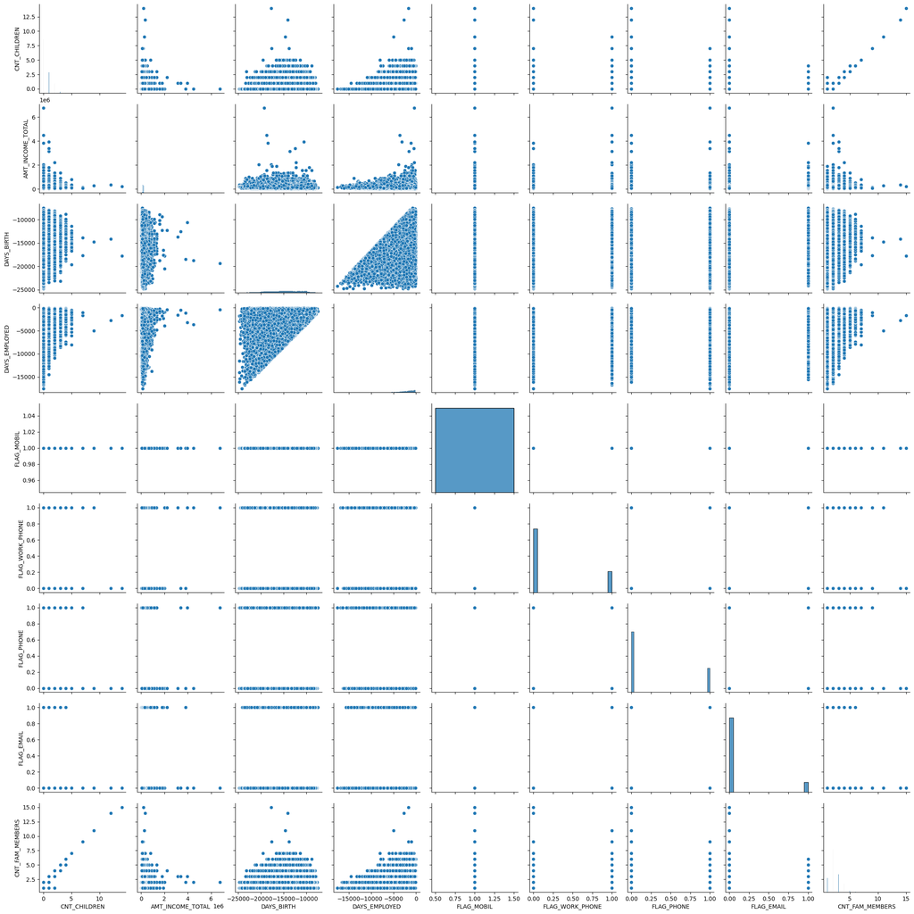

```python
sb.pairplot(data=appRecords)
```

# Finding Things to Explore

There are some questions I can try to answer:

1. What is the average total income (`AMT_INCOME_TOTAL`) of each education type (`NAME_EDUCATION_TYPE`)?
2. Is there a relationship between the number of family members (`CNT_FAM_MEMBERS`) and total income (`AMT_INCOME_TOTAL`)?
3. Does family status (`NAME_FAMILY_STATUS`) affect total income (`AMT_INCOME_TOTAL`)?
4. Which gender (`CODE_GENDER`) is more likely to own a car (`FLAG_OWN_CAR`)?
5. Is there a relationship between income type (`NAME_INCOME_TYPE`) and housing type (`NAME_HOUSING_TYPE`)?
6. What is the relationship between age (`DAYS_BIRTH`) and total income (`AMT_INCOME_TOTAL`)?

This dataset seems to be quite a bit of work, so I should probably find things to talk about. Regardless, the project should revolve around the variable `AMT_INCOME_TOTAL`.

## Income in Relation to Demographics.

```python
appRecords["NAME_INCOME_TYPE"].unique()
```

```
array(['Working', 'State servant', 'Commercial associate', 'Student',
       'Pensioner'], dtype=object)
```

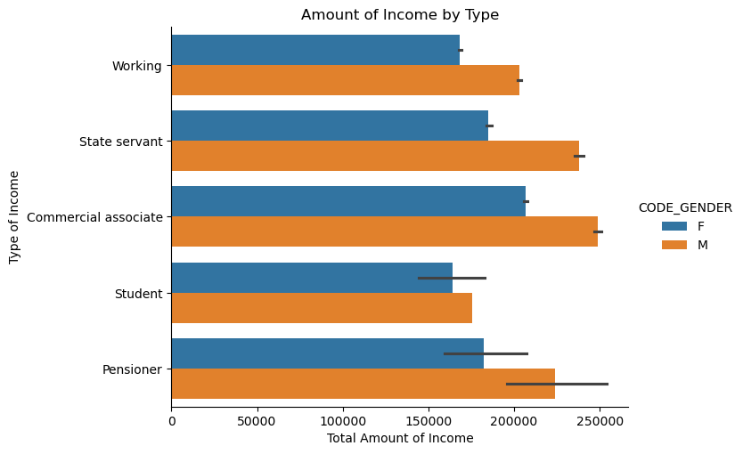

```python
sb.catplot(data=appRecords, y="NAME_INCOME_TYPE", x="AMT_INCOME_TOTAL", hue="CODE_GENDER", kind="bar", height=5, aspect=1.5)
plt.xlabel('Total Amount of Income')
plt.ylabel('Type of Income')
plt.title('Amount of Income by Type')
plt.show()
```

```python
appRecords["NAME_EDUCATION_TYPE"].unique()
```

```
array(['Secondary / secondary special', 'Higher education',
       'Lower secondary', 'Incomplete higher', 'Academic degree'],
      dtype=object)
```

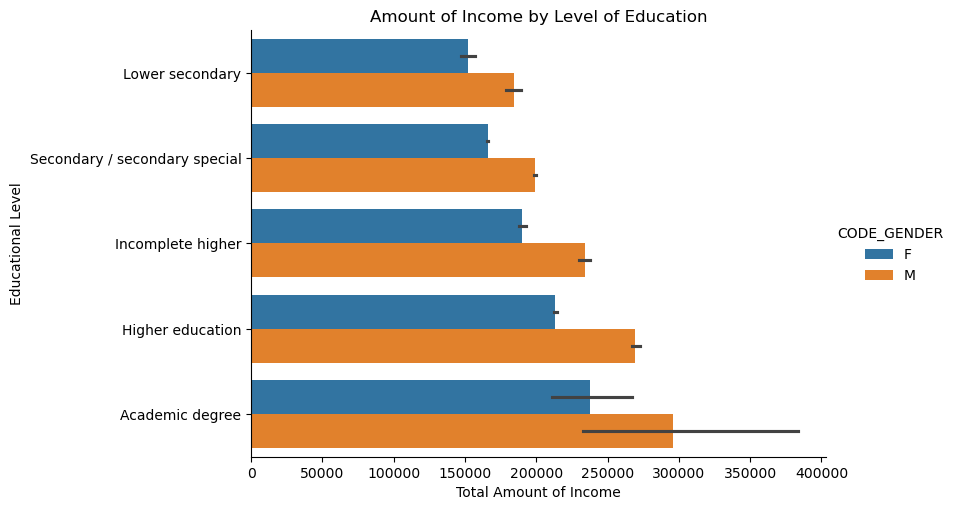

```python
sb.catplot(data=appRecords, y="NAME_EDUCATION_TYPE", x="AMT_INCOME_TOTAL", hue="CODE_GENDER", kind="bar", height=5, aspect=1.75,
           order=['Lower secondary', 'Secondary / secondary special', 'Incomplete higher', 'Higher education', 'Academic degree'])
plt.xlabel('Total Amount of Income')
plt.ylabel('Educational Level')
plt.title('Amount of Income by Level of Education')
plt.show()
```

In general, people with academic degrees tend to have the most total income; and the less educated one is, the less total income one has. Furthermore, at any educational level, men generally make more than women, and the discrepency grows as educational level increases.

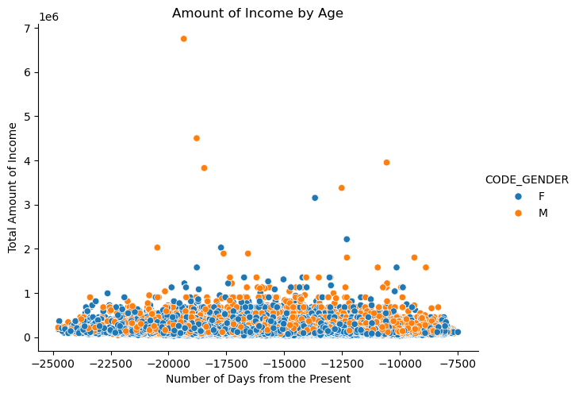

```python
sb.relplot(data=appRecords, x="DAYS_BIRTH", y="AMT_INCOME_TOTAL", hue="CODE_GENDER", height=5, aspect=1.25)
plt.xlabel('Number of Days from the Present')
plt.ylabel('Total Amount of Income')
plt.title('Amount of Income by Age')
plt.show()
```

Note that the more negative `DAYS_BIRTH` is, the older the people are. Most people cannot get past $2 000 000$ dollars in income, which sort of makes sense. I find it interesting how the outliers who make more than $2 000 000$ dollars are mostly male.

## Correlations

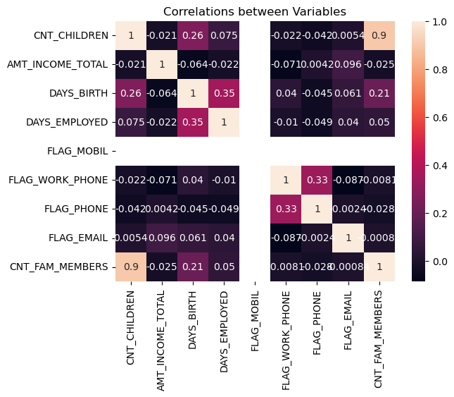

```python
correlation = appRecords.select_dtypes(include=['number']).corr(method="pearson")
sb.heatmap(correlation, annot=True)
plt.title('Correlations between Variables')
plt.show()
```

Oh, no, that is definitely not a good sign.

## Predictive Models

As it stands, the dataset looks rather horrible, but we will proceed with traning, testing, and fitting models. We shall see what will happen.

### Splitting Data

```python
dummyRecords = pd.get_dummies(appRecords)
```

```python
predictors = dummyRecords.drop("AMT_INCOME_TOTAL", axis=1)
outcomes = dummyRecords[["AMT_INCOME_TOTAL"]]
xTrain, xTest, yTrain, yTest = model_selection.train_test_split(predictors, outcomes, test_size = 0.2, random_state = 200)
```

### Ordinary Linear Regression Model

```python
appRecLM = linear_model.LinearRegression().fit(xTrain, yTrain)
```

```python
yPredLMTest = appRecLM.predict(xTest)
yPredLMTrain = appRecLM.predict(xTrain)
```

```python
pd.DataFrame({"Column" : xTest.columns, "Coefficient" : appRecLM.coef_[0]}).sort_values("Coefficient")
```

|  | Column | Coefficient |
| --- | --- | --- |
| 44 | OCCUPATION_TYPE_Low-skill Laborers | -4.142223e+04 |
| 17 | NAME_INCOME_TYPE_Student | -3.915337e+04 |
| 51 | OCCUPATION_TYPE_Security staff | -3.013104e+04 |
| 22 | NAME_EDUCATION_TYPE_Lower secondary | -2.784533e+04 |
| 36 | OCCUPATION_TYPE_Cleaning staff | -2.533216e+04 |
| 8 | CODE_GENDER_F | -1.999495e+04 |
| 23 | NAME_EDUCATION_TYPE_Secondary / secondary special | -1.993259e+04 |
| 4 | FLAG_WORK_PHONE | -1.429502e+04 |
| 37 | OCCUPATION_TYPE_Cooking staff | -1.240697e+04 |
| 29 | NAME_HOUSING_TYPE_Co-op apartment | -1.205707e+04 |
| 10 | FLAG_OWN_CAR_N | -1.173421e+04 |
| 39 | OCCUPATION_TYPE_Drivers | -1.142534e+04 |
| 43 | OCCUPATION_TYPE_Laborers | -1.136579e+04 |
| 34 | NAME_HOUSING_TYPE_With parents | -1.083201e+04 |
| 52 | OCCUPATION_TYPE_Waiters/barmen staff | -1.069796e+04 |
| 25 | NAME_FAMILY_STATUS_Married | -1.016086e+04 |
| 42 | OCCUPATION_TYPE_IT staff | -9.792654e+03 |
| 50 | OCCUPATION_TYPE_Secretaries | -8.795892e+03 |
| 49 | OCCUPATION_TYPE_Sales staff | -4.100941e+03 |
| 30 | NAME_HOUSING_TYPE_House / apartment | -3.550422e+03 |
| 27 | NAME_FAMILY_STATUS_Single / not married | -3.312851e+03 |
| 7 | CNT_FAM_MEMBERS | -3.290950e+03 |
| 46 | OCCUPATION_TYPE_Medicine staff | -1.438308e+03 |
| 12 | FLAG_OWN_REALTY_N | -1.312683e+03 |
| 41 | OCCUPATION_TYPE_High skill tech staff | -6.405710e+02 |
| 1 | DAYS_BIRTH | -3.031053e+00 |
| 2 | DAYS_EMPLOYED | -7.139681e-01 |
| 3 | FLAG_MOBIL | -3.012160e-07 |
| 18 | NAME_INCOME_TYPE_Working | 5.945604e+02 |
| 38 | OCCUPATION_TYPE_Core staff | 7.546875e+02 |
| 13 | FLAG_OWN_REALTY_Y | 1.312683e+03 |
| 21 | NAME_EDUCATION_TYPE_Incomplete higher | 2.013968e+03 |
| 0 | CNT_CHILDREN | 2.786859e+03 |
| 15 | NAME_INCOME_TYPE_Pensioner | 2.853945e+03 |
| 26 | NAME_FAMILY_STATUS_Separated | 3.503497e+03 |
| 33 | NAME_HOUSING_TYPE_Rented apartment | 3.567974e+03 |
| 5 | FLAG_PHONE | 3.860722e+03 |
| 31 | NAME_HOUSING_TYPE_Municipal apartment | 4.892070e+03 |
| 28 | NAME_FAMILY_STATUS_Widow | 4.922753e+03 |
| 24 | NAME_FAMILY_STATUS_Civil marriage | 5.047463e+03 |
| 16 | NAME_INCOME_TYPE_State servant | 8.899965e+03 |
| 11 | FLAG_OWN_CAR_Y | 1.173421e+04 |
| 40 | OCCUPATION_TYPE_HR staff | 1.333499e+04 |
| 20 | NAME_EDUCATION_TYPE_Higher education | 1.362400e+04 |
| 32 | NAME_HOUSING_TYPE_Office apartment | 1.797946e+04 |
| 9 | CODE_GENDER_M | 1.999495e+04 |
| 6 | FLAG_EMAIL | 2.056429e+04 |
| 35 | OCCUPATION_TYPE_Accountants | 2.117887e+04 |
| 47 | OCCUPATION_TYPE_Private service staff | 2.385731e+04 |
| 14 | NAME_INCOME_TYPE_Commercial associate | 2.680490e+04 |
| 19 | NAME_EDUCATION_TYPE_Academic degree | 3.213994e+04 |
| 48 | OCCUPATION_TYPE_Realty agents | 3.914394e+04 |
| 45 | OCCUPATION_TYPE_Managers | 6.928007e+04 |

```python
print(appRecLM.intercept_)
print(metrics.r2_score(yTest, yPredLMTest))
print(metrics.r2_score(yTrain, yPredLMTrain))
print(metrics.root_mean_squared_error(yTest, yPredLMTest))
print(metrics.root_mean_squared_error(yTrain, yPredLMTrain))
```

```
[168840.57086457]
0.16089881076734824
0.1624283208372007
111017.52938100867
107674.32202005704
```

Oh heavens, look at that $R^2$! Though, that is to be expected, given how the dataset looks.

### LASSO

```python
appRecsLASSO = linear_model.Lasso(alpha=11100).fit(xTrain, yTrain)
yPredLASSOTest = appRecsLASSO.predict(xTest)
yPredLASSOTrain = appRecsLASSO.predict(xTrain)
print(metrics.r2_score(yTest, yPredLASSOTest))
print(metrics.r2_score(yTrain, yPredLASSOTrain))
print(metrics.root_mean_squared_error(yTest, yPredLASSOTest))
print(metrics.root_mean_squared_error(yTrain, yPredLASSOTrain))
```

```
0.004975494860922081
0.006118856792172722
120893.03431373349
117291.99663682887
```

LASSO actually performs much worse than the ordinary linear model but seems to 'work' the best at $\alpha = 11100$.

```python
LASSO_coefs = pd.DataFrame({"Column" : xTest.columns, "Coefficient" : appRecsLASSO.coef_}).sort_values("Coefficient")
LASSO_coefs
```

|  | Column | Coefficient |
| --- | --- | --- |
| 23 | NAME_EDUCATION_TYPE_Secondary / secondary special | -1139.676408 |
| 1 | DAYS_BIRTH | -2.227116 |
| 0 | CNT_CHILDREN | -0.000000 |
| 29 | NAME_HOUSING_TYPE_Co-op apartment | 0.000000 |
| 30 | NAME_HOUSING_TYPE_House / apartment | 0.000000 |
| 31 | NAME_HOUSING_TYPE_Municipal apartment | -0.000000 |
| 32 | NAME_HOUSING_TYPE_Office apartment | 0.000000 |
| 33 | NAME_HOUSING_TYPE_Rented apartment | 0.000000 |
| 34 | NAME_HOUSING_TYPE_With parents | -0.000000 |
| 35 | OCCUPATION_TYPE_Accountants | 0.000000 |
| 36 | OCCUPATION_TYPE_Cleaning staff | -0.000000 |
| 37 | OCCUPATION_TYPE_Cooking staff | -0.000000 |
| 38 | OCCUPATION_TYPE_Core staff | -0.000000 |
| 39 | OCCUPATION_TYPE_Drivers | 0.000000 |
| 40 | OCCUPATION_TYPE_HR staff | 0.000000 |
| 41 | OCCUPATION_TYPE_High skill tech staff | 0.000000 |
| 42 | OCCUPATION_TYPE_IT staff | 0.000000 |
| 43 | OCCUPATION_TYPE_Laborers | -0.000000 |
| 44 | OCCUPATION_TYPE_Low-skill Laborers | -0.000000 |
| 45 | OCCUPATION_TYPE_Managers | 0.000000 |
| 46 | OCCUPATION_TYPE_Medicine staff | -0.000000 |
| 47 | OCCUPATION_TYPE_Private service staff | 0.000000 |
| 48 | OCCUPATION_TYPE_Realty agents | 0.000000 |
| 49 | OCCUPATION_TYPE_Sales staff | -0.000000 |
| 50 | OCCUPATION_TYPE_Secretaries | -0.000000 |
| 28 | NAME_FAMILY_STATUS_Widow | -0.000000 |
| 27 | NAME_FAMILY_STATUS_Single / not married | 0.000000 |
| 26 | NAME_FAMILY_STATUS_Separated | 0.000000 |
| 25 | NAME_FAMILY_STATUS_Married | -0.000000 |
| 3 | FLAG_MOBIL | 0.000000 |
| 4 | FLAG_WORK_PHONE | -0.000000 |
| 5 | FLAG_PHONE | 0.000000 |
| 6 | FLAG_EMAIL | 0.000000 |
| 7 | CNT_FAM_MEMBERS | -0.000000 |
| 8 | CODE_GENDER_F | -0.000000 |
| 9 | CODE_GENDER_M | 0.000000 |
| 10 | FLAG_OWN_CAR_N | -0.000000 |
| 11 | FLAG_OWN_CAR_Y | 0.000000 |
| 51 | OCCUPATION_TYPE_Security staff | -0.000000 |
| 12 | FLAG_OWN_REALTY_N | -0.000000 |
| 14 | NAME_INCOME_TYPE_Commercial associate | 0.000000 |
| 15 | NAME_INCOME_TYPE_Pensioner | -0.000000 |
| 16 | NAME_INCOME_TYPE_State servant | 0.000000 |
| 17 | NAME_INCOME_TYPE_Student | -0.000000 |
| 18 | NAME_INCOME_TYPE_Working | -0.000000 |
| 19 | NAME_EDUCATION_TYPE_Academic degree | 0.000000 |
| 20 | NAME_EDUCATION_TYPE_Higher education | 0.000000 |
| 21 | NAME_EDUCATION_TYPE_Incomplete higher | 0.000000 |
| 22 | NAME_EDUCATION_TYPE_Lower secondary | -0.000000 |
| 24 | NAME_FAMILY_STATUS_Civil marriage | 0.000000 |
| 13 | FLAG_OWN_REALTY_Y | 0.000000 |
| 52 | OCCUPATION_TYPE_Waiters/barmen staff | -0.000000 |
| 2 | DAYS_EMPLOYED | 0.018474 |

All variables have coefficient $0$ *except* the following:

```python
LASSO_coefs[LASSO_coefs["Coefficient"]!=0]
```

|  | Column | Coefficient |
| --- | --- | --- |
| 23 | NAME_EDUCATION_TYPE_Secondary / secondary special | -1139.676408 |
| 1 | DAYS_BIRTH | -2.227116 |
| 2 | DAYS_EMPLOYED | 0.018474 |

### Comparison between Linear Models

```python
compareLM = pd.DataFrame({"Actual" : np.ravel(yTest),
                          "Ordinary" : np.ravel(yPredLMTest),
                          "LASSO" : yPredLASSOTest})
```

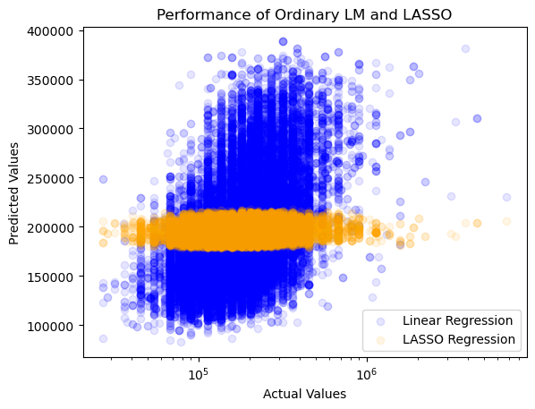

```python
plt.scatter(compareLM[["Actual"]], compareLM[["Ordinary"]], color='blue', alpha=0.1, label='Linear Regression')
plt.scatter(compareLM[["Actual"]], compareLM[["LASSO"]], color='orange', alpha=0.1, label='LASSO Regression')
plt.xscale('log')
plt.xlabel('Actual Values')
plt.ylabel('Predicted Values')
plt.title('Performance of Ordinary LM and LASSO')
plt.legend()
plt.show()
```